# Intelligent Systems. Hands-on 3 (NER)

Aziz Nabil

20/12/2019

### Functions declaration :

```r
#getAnnotationsFromDocument
#getAnnotationsFromDocument returns annotations for the text document: word, sentence, #part-of-speech, and Penn Treebank parse annotations.
getAnnotationsFromDocument = function(doc){
  x=as.String(doc)
  sent_token_annotator <- Maxent_Sent_Token_Annotator()
  word_token_annotator <- Maxent_Word_Token_Annotator()
  pos_tag_annotator <- Maxent_POS_Tag_Annotator()
  y1 <- annotate(x, list(sent_token_annotator, word_token_annotator))
  y2 <- annotate(x, pos_tag_annotator, y1)
  gc()
  return(y2)
}

#getAnnotatedMergedDocument
#getAnnotatedMergedDocument returns the text document merged with the annotations.
getAnnotatedMergedDocument = function(doc,annotations){
  x=as.String(doc)
  y2w <- subset(annotations, type == "word")
  tags <- sapply(y2w$features, '[[', "POS")
  r1 <- sprintf("%s/%s", x[y2w], tags)
  r2 <- paste(r1, collapse = " ")
  return(r2)
}
#getAnnotatedPlainTextDocument
#returns the text document along with its annotations in an AnnotatedPlainTextDocument.
getAnnotatedPlainTextDocument = function(doc,annotations){
  x=as.String(doc)
  a = AnnotatedPlainTextDocument(x,annotations)
  return(a)
}
#detectPatternOnDocument
detectPatternOnDocument <- function(doc, pattern) {
  x=as.String(doc)
  res=str_match_all(x,pattern)

  dimrow=dim(res[[1]])[1]
  dimcol=dim(res[[1]])[2]

  # If there are no rows, no matches have been found
  if (dimrow == 0) {
    return(NA)
  }else{
    if (dimcol > 2){
      # If there are three or more columns, we have to paste all the groups together
      for (i in 1:dimrow) {
        res[[1]][i,2] = paste(res[[1]][i,2:dimcol], collapse = ' ')
      }
    }

    # We return all the results found separated by ','
    if (dimcol != 1) {
      result = paste(res[[1]][,2], collapse = ', ')
    }else{
      result = paste(res[[1]][,1], collapse = ', ')
    }
    return(result)
  }
}
#detectPatternOnDocumentWithContext
detectPatternOnDocumentWithContext <- function(doc, pattern) {
  txt=as.String(doc)
  number=50
  coord=str_locate(txt,pattern)
  res3=substr(txt,coord[1]-number,coord[2]+number)
  return (res3)
}
#detectPatternsInCorpus
detectPatternsInCorpus = function(corpus, patterns){
  vallEntities <- data.frame(matrix(NA, ncol = length(patterns)+1,
                                    nrow = length(corpus)))
  names(vallEntities) <- c("File",patterns)
  for (i in 1:length(patterns)) {
    vallEntities[,i+1]=unlist(lapply(corpus, detectPatternOnDocument,
                                     pattern=patterns[i]))
    }
  for (i in 1:length(corpus)) {
    vallEntities$File[i]=meta(corpus[[i]])$id
    }
  return (vallEntities)
}
#detectPatternsInTaggedCorpus
detectPatternsInTaggedCorpus = function(corpus, taggedCorpus, patterns){
  vallEntities <- data.frame(matrix(NA, ncol = length(patterns)+1,
                                    nrow = length(corpus)))
  names(vallEntities) <- c("File",patterns)
  for (i in 1:length(patterns)) {
    vallEntities[,i+1]=unlist(lapply(taggedCorpus, detectPatternOnDocument,
                                     pattern=patterns[i]))
    }
  for (i in 1:length(corpus)) {
    vallEntities$File[i]=meta(corpus[[i]])$id
    }
  return (vallEntities)
}
#countMatchesPerColumn
countMatchesPerColumn = function (df) {
  entityCountPerPattern <- data.frame(matrix(NA, ncol = 2,
                                             nrow = length(names(df))-1))
  names(entityCountPerPattern) <- c("Entity","Count")

  for (i in 2:length(names(df))) {
    entityCountPerPattern$Entity[i-1] = names(df)[i]
    entityCountPerPattern$Count[i-1] = nrow(subset(df, !is.na(df[i])))
    }
  return (entityCountPerPattern)
}
#countMatchesPerRow
countMatchesPerRow = function (df) {
  entityCountPerFile <- data.frame(matrix(NA, ncol = 2, nrow = nrow(df)))
  names(entityCountPerFile) <- c("File","Count")

  for (i in 1:nrow(df)) {
    entityCountPerFile$File[i] = df$File[i]
    entityCountPerFile$Count[i] = length(Filter(Negate(is.na),df[i,2:length(df[i,])]))
    }
  return (entityCountPerFile[entityCountPerFile[2]!=0,])
}
#printMatchesPerPattern
printMatchesPerPattern = function (patterns, matches) {
  for (i in 1:length(patterns)){
    print(paste("PATTERN: ",patterns[i]))
    strings = matches[,i+1][!is.na(unlist(matches[,i+1]))]
    print(strings)
    print(" ")
  }
}
#mergeAllMatchesInLists
mergeAllMatchesInLists = function (df) {
  matchesPerFile = rep(list(list()), nrow(df))
  for (i in 1:nrow(df)) {
    matches=list()
    for (j in 2:ncol(df)){
      if (grepl(',',df[i,j])){
        b=strsplit(as.character(df[i,j]),split=',')
        for (j in 1:length(b[[1]])){
          matches= c(matches,str_trim(b[[1]][j]))
        }
      }else{
        if (!(is.na(df[i,j]))){
          matches = c(matches,str_trim(df[i,j]))
        }
      }
    }
    matches = unique(matches)
    matchesPerFile[[i]]=append(matchesPerFile[[i]],matches)
  }

  files = df[,1]
  matches = matchesPerFile

  allMatches<- data.frame(matrix(NA, ncol = 2, nrow = nrow(df)))
  names(allMatches) <- c("Files","Matches")

  allMatches$Files=files
  allMatches$Matches=matches

  return (allMatches)
}
#mergeGoldStandardInLists
mergeGoldStandardInLists = function (df) {
  matchesPerFile = rep(list(list()), nrow(df))

  for (i in 1:nrow(df)) {
    matches=as.list(unlist(Filter(Negate(is.na),df[i,2:length(df)])))
    matchesPerFile[[i]]=append(matchesPerFile[[i]],matches)
  }

  files = df[,1]
  matches = matchesPerFile

  allMatches<- data.frame(matrix(NA, ncol = 2, nrow = nrow(df)))
  names(allMatches) <- c("Files","Matches")

  allMatches$Files=files
  allMatches$Matches=matches

  return (allMatches)
}
#calculateMetrics
calculateMetrics = function (matches, matches.gs) {

  metrics<- data.frame(matrix(NA, ncol = 3, nrow = 1))
  names(metrics) <- c("Precision","Recall","Fmeasure")

  numCorrect = 0
  allAnswers = 0
  possibleAnswers = 0

  for (i in 1:nrow(matches)) {
    if (length(matches.gs$Matches[[i]])!=0) {
      l = str_trim(unlist(matches[i,2]))
      l.gs = unname(unlist(matches.gs[i,2]))
      intersection = intersect(l, l.gs)
      numCorrect = numCorrect + length(intersect(l, l.gs))
      allAnswers = allAnswers + length (l)
      possibleAnswers = possibleAnswers + length(l.gs)
    }
  }

  metrics$Precision = numCorrect / allAnswers
  metrics$Recall = numCorrect / possibleAnswers

  beta = 1
  if ((metrics$Precision == 0) & (metrics$Recall == 0)) {
    metrics$Fmeasure = 0
  } else {
    metrics$Fmeasure = ((sqrt(beta)+1) * metrics$Precision * metrics$Recall) /
      ((sqrt(beta)*metrics$Precision) + metrics$Recall)
  }

  return(metrics)
}
```

### loading files and inspecting documents

- Loading corpus data from a local directory

```r
source.pos = DirSource("E:\\intelligent systems\\unit_4\\txt_sentoken\\pos", encoding = "UTF-8")
corpus = Corpus(source.pos)
```

- getting the documents and inspect the first document.

```r
meta(corpus[[1]])$id
```

```
## [1] "cv000_29590.txt"
```

```r
inspect(corpus[[1]])
```

```
## <<PlainTextDocument>>
## Metadata:  7
## Content:  chars: 4226
##
## films adapted from comic books have had plenty of success , whether they're about superheroes ( batman , superman , spawn ) , or geared toward kids ( casper ) or the arthouse crowd ( ghost world ) , but there's never really been a comic book like from hell before .
## for starters , it was created by alan moore ( and eddie campbell ) , who brought the medium to a whole new level in the mid '80s with a 12-part series called the watchmen .
## to say moore and campbell thoroughly researched the subject of jack the ripper would be like saying michael jackson is starting to look a little odd .
## the book ( or " graphic novel , " if you will ) is over 500 pages long and includes nearly 30 more that consist of nothing but footnotes .
## in other words , don't dismiss this film because of its source .
## if you can get past the whole comic book thing , you might find another stumbling block in from hell's directors , albert and allen hughes .
## getting the hughes brothers to direct this seems almost as ludicrous as casting carrot top in , well , anything , but riddle me this : who better to direct a film that's set in the ghetto and features really violent street crime than the mad geniuses behind menace ii society ?
## the ghetto in question is , of course , whitechapel in 1888 london's east end .
## it's a filthy , sooty place where the whores ( called " unfortunates " ) are starting to get a little nervous about this mysterious psychopath who has been carving through their profession with surgical precision .
## when the first stiff turns up , copper peter godley ( robbie coltrane , the world is not enough ) calls in inspector frederick abberline ( johnny depp , blow ) to crack the case .
## abberline , a widower , has prophetic dreams he unsuccessfully tries to quell with copious amounts of absinthe and opium .
## upon arriving in whitechapel , he befriends an unfortunate named mary kelly ( heather graham , say it isn't so ) and proceeds to investigate the horribly gruesome crimes that even the police surgeon can't stomach .
## i don't think anyone needs to be briefed on jack the ripper , so i won't go into the particulars here , other than to say moore and campbell have a unique and interesting theory about both the identity of the killer and the reasons he chooses to slay .
## in the comic , they don't bother cloaking the identity of the ripper , but screenwriters terry hayes ( vertical limit ) and rafael yglesias ( les mis ? rables ) do a good job of keeping him hidden from viewers until the very end .
## it's funny to watch the locals blindly point the finger of blame at jews and indians because , after all , an englishman could never be capable of committing such ghastly acts .
## and from hell's ending had me whistling the stonecutters song from the simpsons for days ( " who holds back the electric car/who made steve guttenberg a star ? " ) .
## don't worry - it'll all make sense when you see it .
## now onto from hell's appearance : it's certainly dark and bleak enough , and it's surprising to see how much more it looks like a tim burton film than planet of the apes did ( at times , it seems like sleepy hollow 2 ) .
## the print i saw wasn't completely finished ( both color and music had not been finalized , so no comments about marilyn manson ) , but cinematographer peter deming ( don't say a word ) ably captures the dreariness of victorian-era london and helped make the flashy killing scenes remind me of the …
## oscar winner martin childs' ( shakespeare in love ) production design turns the original prague surroundings into one creepy place .
## even the acting in from hell is solid , with the dreamy depp turning in a typically strong performance and deftly handling a british accent .
## ians holm ( joe gould's secret ) and richardson ( 102 dalmatians ) log in great supporting roles , but the big surprise here is graham .
## i cringed the first time she opened her mouth , imagining her attempt at an irish accent , but it actually wasn't half bad .
## the film , however , is all good .
## 2 : 00 - r for strong violence/gore , sexuality , language and drug content
```

### making Annotations :

- applying the getAnnotationsFromDocument function to corpus.

```r
annotations = lapply(corpus, getAnnotationsFromDocument)
```

- The annotations are sentence annotations generated by the head function.

```r
head(annotations[[1]])
```

```
##  id type     start end  features
##   1 sentence     1  265 constituents=<<integer,54>>
##   2 sentence   268  439 constituents=<<integer,36>>
##   3 sentence   442  591 constituents=<<integer,27>>
##   4 sentence   594  797 constituents=<<integer,44>>
##   5 sentence   800  939 constituents=<<integer,28>>
##   6 sentence   942 1299 constituents=<<integer,70>>
```

- Word annotations generated by tail function.

```r
tail(annotations[[1]])
```

```
##  id  type start end  features
##  844 word  4189 4197 POS=NN
##  845 word  4199 4199 POS=,
##  846 word  4201 4208 POS=NN
##  847 word  4210 4212 POS=CC
##  848 word  4214 4217 POS=NN
##  849 word  4219 4225 POS=NN
```

- creating AnnotatedPlainTextDocuments that attach the annotations to the document and store the annotated corpus in another variable .

```r
corpus.tagged = Map(getAnnotatedPlainTextDocument, corpus, annotations)
inspect(corpus.tagged[[1]])
```

```
## <<AnnotatedPlainTextDocument>>
## Metadata:  0
## Annotations:  length: 849
## Content:  chars: 4226
##
## films adapted from comic books have had plenty of success , whether they're about superheroes ( batman , superman , spawn ) , or geared toward kids ( casper ) or the arthouse crowd ( ghost world ) , but there's never really been a comic book like from hell before .
## for starters , it was created by alan moore ( and eddie campbell ) , who brought the medium to a whole new level in the mid '80s with a 12-part series called the watchmen .
## to say moore and campbell thoroughly researched the subject of jack the ripper would be like saying michael jackson is starting to look a little odd .
## the book ( or " graphic novel , " if you will ) is over 500 pages long and includes nearly 30 more that consist of nothing but footnotes .
## in other words , don't dismiss this film because of its source .
## if you can get past the whole comic book thing , you might find another stumbling block in from hell's directors , albert and allen hughes .
## getting the hughes brothers to direct this seems almost as ludicrous as casting carrot top in , well , anything , but riddle me this : who better to direct a film that's set in the ghetto and features really violent street crime than the mad geniuses behind menace ii society ?
## the ghetto in question is , of course , whitechapel in 1888 london's east end .
## it's a filthy , sooty place where the whores ( called " unfortunates " ) are starting to get a little nervous about this mysterious psychopath who has been carving through their profession with surgical precision .
## when the first stiff turns up , copper peter godley ( robbie coltrane , the world is not enough ) calls in inspector frederick abberline ( johnny depp , blow ) to crack the case .
## abberline , a widower , has prophetic dreams he unsuccessfully tries to quell with copious amounts of absinthe and opium .
## upon arriving in whitechapel , he befriends an unfortunate named mary kelly ( heather graham , say it isn't so ) and proceeds to investigate the horribly gruesome crimes that even the police surgeon can't stomach .
## i don't think anyone needs to be briefed on jack the ripper , so i won't go into the particulars here , other than to say moore and campbell have a unique and interesting theory about both the identity of the killer and the reasons he chooses to slay .
## in the comic , they don't bother cloaking the identity of the ripper , but screenwriters terry hayes ( vertical limit ) and rafael yglesias ( les mis ? rables ) do a good job of keeping him hidden from viewers until the very end .
## it's funny to watch the locals blindly point the finger of blame at jews and indians because , after all , an englishman could never be capable of committing such ghastly acts .
## and from hell's ending had me whistling the stonecutters song from the simpsons for days ( " who holds back the electric car/who made steve guttenberg a star ? " ) .
## don't worry - it'll all make sense when you see it .
## now onto from hell's appearance : it's certainly dark and bleak enough , and it's surprising to see how much more it looks like a tim burton film than planet of the apes did ( at times , it seems like sleepy hollow 2 ) .
## the print i saw wasn't completely finished ( both color and music had not been finalized , so no comments about marilyn manson ) , but cinematographer peter deming ( don't say a word ) ably captures the dreariness of victorian-era london and helped make the flashy killing scenes remind me of the …
## oscar winner martin childs' ( shakespeare in love ) production design turns the original prague surroundings into one creepy place .
## even the acting in from hell is solid , with the dreamy depp turning in a typically strong performance and deftly handling a british accent .
## ians holm ( joe gould's secret ) and richardson ( 102 dalmatians ) log in great supporting roles , but the big surprise here is graham .
## i cringed the first time she opened her mouth , imagining her attempt at an irish accent , but it actually wasn't half bad .
## the film , however , is all good .
## 2 : 00 - r for strong violence/gore , sexuality , language and drug content
```

- storing all the annotations inline with the text and store the annotated corpus in another variable .

```r
corpus.taggedText = Map(getAnnotatedMergedDocument, corpus, annotations)
corpus.taggedText[[1]]
```

```
## [1] "films/NNS adapted/VBD from/IN comic/JJ books/NNS have/VBP had/VBN plenty/NN of/IN success/NN ,/, whether/IN they/PRP 're/VBP about/IN superheroes/NNS (/-LRB- batman/NN ,/, superman/NN ,/, spawn/NN )/-RRB- ,/, or/CC geared/VBN toward/IN kids/NNS (/-LRB- casper/NN )/-RRB- or/CC the/DT arthouse…
```

### Finding simple patterns

- those are some simple string patterns to try to identify people appearances.

```r
pattern0=c("created by")
pattern0=c(pattern0,"screenwriter[s]?")
pattern0=c(pattern0,"cinematographer")
pattern0=c(pattern0,"oscar winner")
```

- We detect those patterns in the corpus and we can see in which files they do appear.

```r
matches0 = detectPatternsInCorpus(corpus, pattern0)
matches0[!is.na(matches0[3]),c(1,3)]
```

```
##                File
## 1   cv000_29590.txt
## 29  cv028_26746.txt
## 30  cv029_18643.txt
## 77  cv076_24945.txt
## 79  cv078_14730.txt
## 87  cv086_18371.txt
## 95  cv094_27889.txt
## 116 cv115_25396.txt
## 122 cv121_17302.txt
## 136 cv135_11603.txt
## 143 cv142_22516.txt
## 144 cv143_19666.txt
## 159 cv158_10390.txt
## 163 cv162_10424.txt
```

[output cut: 155 more lines]

- We check how many patterns we have found in each file.

```r
countMatchesPerRow(matches0)
```

```
##                File Count
## 1   cv000_29590.txt     4
## 29  cv028_26746.txt     1
## 30  cv029_18643.txt     1
## 68  cv067_19774.txt     1
## 77  cv076_24945.txt     1
## 79  cv078_14730.txt     1
## 87  cv086_18371.txt     1
## 95  cv094_27889.txt     1
## 100 cv099_10534.txt     1
## 109 cv108_15571.txt     1
## 116 cv115_25396.txt     1
## 122 cv121_17302.txt     2
## 136 cv135_11603.txt     1
## 143 cv142_22516.txt     1
```

[output cut: 119 more lines]

- And we check how many times each pattern has been found.

```r
countMatchesPerColumn(matches0)
```

```
##             Entity Count
## 1       created by     9
## 2 screenwriter[s]?    84
## 3  cinematographer    42
## 4     oscar winner     8
```

- And we print the context in which the patterns are found, to see if we can build better patterns.

```r
for (i in 1:length(pattern0)){
  print(paste("PATTERN: ",pattern0[i]))
  strings = lapply(corpus, detectPatternOnDocumentWithContext, pattern=pattern0[i])
  print(unlist(strings[!is.na(unlist(strings))]))
  print(" ")
}
```

```
## [1] "PATTERN:  created by"
##                                                                                                    cv000_29590.txt
##  "ok like from hell before . \nfor starters , it was created by alan moore ( and eddie campbell ) , who brought t"
##                                                                                                     cv205_9457.txt
##  "turvy . \nrobert zemeckis , back from the euphoria created by his last film , forrest gump , once again proves "
##                                                                                                    cv285_16494.txt
##  "ve got mail like dried-up mistletoe . \nthe sparks created by the earlier movie are , by necessity , not eviden"
##                                                                                                     cv324_7082.txt
##  "the real thing . \nthe two of them , as characters created by fingal's imagination , serve as aspects of his pe"
##                                                                                                     cv371_7630.txt
##  "nd always right on the mark , enhancing the moods created by the animated scenery . \nas far as the subtitles g"
##                                                                                                    cv484_25054.txt
##   " and there are cliches , but the walls of water , created by fluid dynamics simulating real-life phenomena , a"
##                                                                                                    cv628_19325.txt
##  " on the story `tarzan of the apes' and characters created by edgar rice burroughs . \nseen july 4 , 1999 at 7 :"
##                                                                                                    cv743_15449.txt
##  "nt of a bug's life is the quality of animation . \ncreated by pixar , the same people who brought us toy story "
##                                                                                                    cv892_17576.txt
## " antagonists in the movie , a group of \" agents \" created by the matrix in its computer program , all dress in"
## [1] " "
## [1] "PATTERN:  screenwriter[s]?"
##                                                                                                          cv000_29590.txt
##      " bother cloaking the identity of the ripper , but screenwriters terry hayes ( vertical limit ) and rafael yglesia"
##                                                                                                          cv028_26746.txt
##   "d the story is so complex and \" clever \" that the screenwriters are the first to get lost in it . \nthere is is no"
##                                                                                                          cv029_18643.txt
##       "mise certainly is interesting and director and co-screenwriter alex proyas is able to keep the film consistently"
##                                                                                                          cv076_24945.txt
##    " logical confusion . \ndirector gregory hoblit and screenwriter toby emmerich structure \" frequency \" as good hol"
##                                                                                                          cv078_14730.txt
##       "different , it would be easy for the director and screenwriter to dumb it down and appeal to the lowest common d"
##                                                                                                          cv086_18371.txt
##      "itively made . \ndirector michael winterbottom and screenwriter frank cottrell boyce vividly express the societal"
##                                                                                                          cv094_27889.txt
##     "it prince acquit themselves admirably . \nkudos to screenwriters james schamus , wang hui ling and tsai kuo jing ,"
##                                                                                                          cv115_25396.txt
##      "ins an interesting character . \npark , lord , and screenwriter karey kirkpatrick realize that an audience does n"
##                                                                                                          cv121_17302.txt
##      "i relish those rare opportunities when a talented screenwriter can make me feel like a fool . \ni spent the first"
##                                                                                                          cv135_11603.txt
```

[output cut: 239 more lines]

```
##                                                                                                        cv108_15571.txt
##    "sshoppers is hopper , who is fiendishly voiced by oscar winner kevin spacey . \nwhen the offering is lost hopper "
##                                                                                                        cv300_22284.txt
##    " he stole every scene he was in away from veteran oscar winner tom hanks . \nrockwell , an independent film veter"
##                                                                                                        cv314_14422.txt
##     "eresting to see that this movie was one of future oscar winner susan sarandon's ( dead man walking ) first film-"
##                                                                                                        cv317_24049.txt
##     " the former actually had the insight to follow up oscar winner usual suspects with a pauly shore vehicle , and j"
##                                                                                                        cv475_21692.txt
##    "on and ben affleck in the starring roles . \nbeing oscar winners for the classic 'good will hunting' they give gr"
##                                                                                                        cv689_12587.txt
## "ances with wolves \" by way of \" out of africa \" ( oscar winners both for barry ) . \nfortunately , barry's replac"
##                                                                                                        cv700_21947.txt
##    "the talent with her that one would expect from an oscar winner . \nrobbie coltrane was easily one of the best par"
## [1] " "
```

### Find entities (complex regular expressions)

- Now we define more complex regular expressions that help identifying people appearances.

```r
pattern1=c("created by ([A-z]* [A-z]*)")
pattern1=c(pattern1,"created by [A-z]* [A-z]* \\( and ([A-z]* [A-z]*)")
pattern1=c(pattern1,"screenwriter[s]? ([A-z]* [A-z]*)")
pattern1=c(pattern1,"cinematographer(?: ,)? ([A-z]* [A-z]*)")
pattern1=c(pattern1,"oscar winner ([A-z]* [A-z]*)")
```

- We detect those patterns in the corpus and we can see in which files they do appear.

```r
matches1 = detectPatternsInCorpus(corpus, pattern1)
matches1[!is.na(matches1[4]),c(1,4)]
```

```
##                File screenwriter[s]? ([A-z]* [A-z]*)
## 1   cv000_29590.txt                      terry hayes
## 29  cv028_26746.txt                          are the
## 30  cv029_18643.txt                      alex proyas
## 77  cv076_24945.txt                    toby emmerich
## 79  cv078_14730.txt                          to dumb
## 87  cv086_18371.txt                   frank cottrell
## 95  cv094_27889.txt                    james schamus
## 116 cv115_25396.txt                karey kirkpatrick
## 122 cv121_17302.txt                         can make
## 144 cv143_19666.txt                               j
## 159 cv158_10390.txt                     paul rudnick
## 163 cv162_10424.txt                      amongst the
## 179 cv178_12972.txt                          for the
## 191 cv190_27052.txt                           of the
```

[output cut: 55 more lines]

- We print the matches found per pattern.

```r
printMatchesPerPattern(pattern1, matches1)
```

```
## [1] "PATTERN:  created by ([A-z]* [A-z]*)"
## [1] "alan moore"     "his last"       "the earlier"    "the animated"
## [5] "fluid dynamics" "edgar rice"     "pixar "         "the matrix"
## [1] " "
## [1] "PATTERN:  created by [A-z]* [A-z]* \\( and ([A-z]* [A-z]*)"
## [1] "eddie campbell"
## [1] " "
## [1] "PATTERN:  screenwriter[s]? ([A-z]* [A-z]*)"
##  [1] "terry hayes"        "are the"            "alex proyas"
##  [4] "toby emmerich"      "to dumb"            "frank cottrell"
##  [7] "james schamus"      "karey kirkpatrick"  "can make"
## [10] "j "                 "paul rudnick"       "amongst the"
## [13] "for the"            "of the"             "marc klein"
## [16] "andy breckman"      "use the"            "ehren kruger"
## [19] "karey kirkpatrick"  "kevin williamson"   "kevin williamson"
```

[output cut: 37 more lines]

- We check how many patterns we have found in each file.

```r
countMatchesPerRow(matches1)
```

```
##                File Count
## 1   cv000_29590.txt     5
## 29  cv028_26746.txt     1
## 30  cv029_18643.txt     1
## 68  cv067_19774.txt     1
## 77  cv076_24945.txt     1
## 79  cv078_14730.txt     1
## 87  cv086_18371.txt     1
## 95  cv094_27889.txt     1
## 100 cv099_10534.txt     1
## 109 cv108_15571.txt     1
## 116 cv115_25396.txt     1
## 122 cv121_17302.txt     2
## 144 cv143_19666.txt     1
## 155  cv154_9328.txt     1
```

[output cut: 100 more lines]

- And we check how many times each pattern has been found.

```r
countMatchesPerColumn(matches1)
```

```
##                                             Entity Count
## 1                       created by ([A-z]* [A-z]*)     8
## 2 created by [A-z]* [A-z]* \\( and ([A-z]* [A-z]*)     1
## 3                 screenwriter[s]? ([A-z]* [A-z]*)    69
## 4           cinematographer(?: ,)? ([A-z]* [A-z]*)    40
## 5                     oscar winner ([A-z]* [A-z]*)     5
```

### Find entities using part-of-speech (POS) tags

- Now we include in our regular expressions part-of-speech information to avoid having incorrect answers.

```r
pattern2=c("created/VBN by/IN ([A-z]*)/NN ([A-z]*)/NN")
pattern2=c(pattern2,"created/VBN by/IN [A-z]*/NN [A-z]*/NN \\(/-LRB- and/CC ([A-z]*)/JJ ([A-z]*)/NN")
pattern2=c(pattern2,"screenwriter[s]?/NN[S]? ([A-z]*)/(?:NN[S]?|JJ) ([A-z]*)/(?:NN|JJ)")
pattern2=c(pattern2,"cinematographer/NN(?: ,/,)? ([A-z]*)/NN ([A-z]*)/NN")
pattern2=c(pattern2,"cinematographer/NN(?: ,/,)? ([A-z]*)/NN ([A-z]*)/IN ([A-z]*)/NN")
pattern2=c(pattern2,"oscar/NN winner/NN ([A-z]*)/VBG ([A-z]*)/NNS")
```

- We detect those patterns in the POS-tagged corpus.

```r
allEntities = detectPatternsInTaggedCorpus(corpus, corpus.taggedText, pattern2)
allEntities[!is.na(allEntities[4]),c(1,4)]
```

```
##                File
## 1   cv000_29590.txt
## 30  cv029_18643.txt
## 77  cv076_24945.txt
## 87  cv086_18371.txt
## 95  cv094_27889.txt
## 116 cv115_25396.txt
## 192 cv191_29719.txt
## 226 cv225_29224.txt
## 242 cv241_23130.txt
## 275 cv274_25253.txt
## 433 cv432_14224.txt
## 453  cv452_5088.txt
## 465 cv464_15650.txt
## 477 cv476_16856.txt
```

[output cut: 41 more lines]

- We can also view the entities for a certain pattern.

```r
Filter(Negate(is.na),allEntities[[4]])
```

```
##  [1] "terry hayes"       "alex proyas"       "toby emmerich"
##  [4] "frank cottrell"    "james schamus"     "karey kirkpatrick"
##  [7] "marc klein"        "andy breckman"     "ehren kruger"
## [10] "karey kirkpatrick" "david goyer"       "larry ferguson"
## [13] "john eskow"        "david duncan"      "elizabeth jane"
## [16] "mark christopher"  "mary harron"       "scott b"
## [19] "john hodge"        "marc norman"       "lawrence wright"
## [22] "john august"       "jeffrey reddick"   "glen morgan"
## [25] "dana stevens"      "rafael yglesias"   "steven gevedon"
```

```r
printMatchesPerPattern(pattern2, allEntities)
```

```
## [1] "PATTERN:  created/VBN by/IN ([A-z]*)/NN ([A-z]*)/NN"
## [1] "alan moore"     "fluid dynamics" "edgar rice"
## [1] " "
## [1] "PATTERN:  created/VBN by/IN [A-z]*/NN [A-z]*/NN \\(/-LRB- and/CC ([A-z]*)/JJ ([A-z]*)/NN"
## [1] "eddie campbell"
## [1] " "
## [1] "PATTERN:  screenwriter[s]?/NN[S]? ([A-z]*)/(?:NN[S]?|JJ) ([A-z]*)/(?:NN|JJ)"
##  [1] "terry hayes"       "alex proyas"       "toby emmerich"
##  [4] "frank cottrell"    "james schamus"     "karey kirkpatrick"
##  [7] "marc klein"        "andy breckman"     "ehren kruger"
## [10] "karey kirkpatrick" "david goyer"       "larry ferguson"
## [13] "john eskow"        "david duncan"      "elizabeth jane"
## [16] "mark christopher"  "mary harron"       "scott b"
## [19] "john hodge"        "marc norman"       "lawrence wright"
## [22] "john august"       "jeffrey reddick"   "glen morgan"
```

[output cut: 18 more lines]

- We count all the entities per pattern. And we can also draw a histogram of the counts.

```r
entityCountPerPattern = countMatchesPerColumn(allEntities)
entityCountPerPattern
```

```
##                                                                           Entity
## 1                                      created/VBN by/IN ([A-z]*)/NN ([A-z]*)/NN
## 2 created/VBN by/IN [A-z]*/NN [A-z]*/NN \\(/-LRB- and/CC ([A-z]*)/JJ ([A-z]*)/NN
## 3              screenwriter[s]?/NN[S]? ([A-z]*)/(?:NN[S]?|JJ) ([A-z]*)/(?:NN|JJ)
## 4                            cinematographer/NN(?: ,/,)? ([A-z]*)/NN ([A-z]*)/NN
## 5                cinematographer/NN(?: ,/,)? ([A-z]*)/NN ([A-z]*)/IN ([A-z]*)/NN
## 6                                   oscar/NN winner/NN ([A-z]*)/VBG ([A-z]*)/NNS
##   Count
## 1     3
## 2     1
## 3    27
## 4    22
## 5     1
## 6     1
```

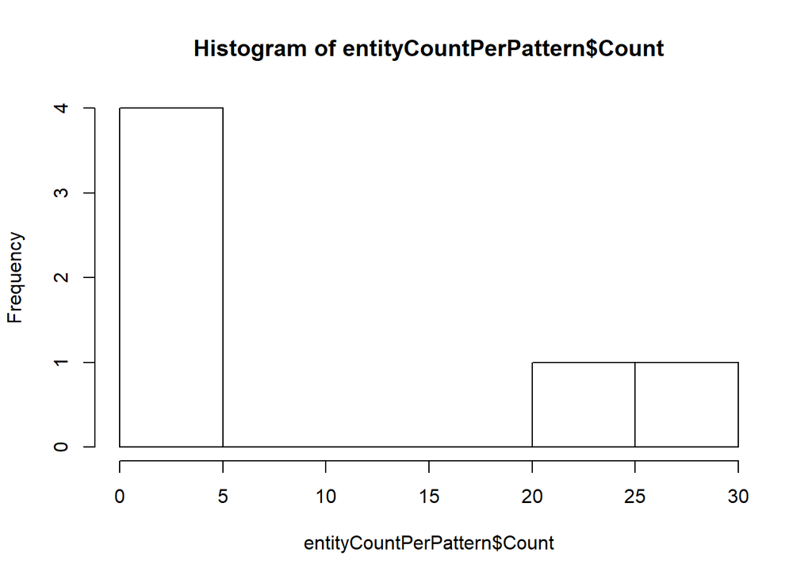

```r
hist(entityCountPerPattern$Count)
```

* We count all the entities per file.

And we can also draw a histogram of the counts.

```r
entityCountPerFile=countMatchesPerRow(allEntities)
entityCountPerFile
```

```
##                File Count
## 1   cv000_29590.txt     5
## 30  cv029_18643.txt     1
## 68  cv067_19774.txt     1
## 77  cv076_24945.txt     1
## 87  cv086_18371.txt     1
## 95  cv094_27889.txt     1
## 100 cv099_10534.txt     1
## 116 cv115_25396.txt     1
## 122 cv121_17302.txt     1
## 155  cv154_9328.txt     1
## 192 cv191_29719.txt     1
## 216 cv215_22240.txt     1
## 226 cv225_29224.txt     1
## 242 cv241_23130.txt     1
```

[output cut: 35 more lines]

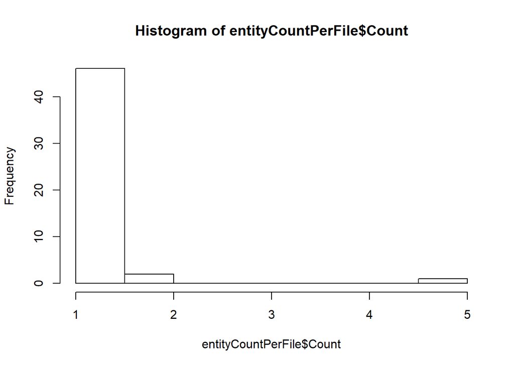

```r
hist(entityCountPerFile$Count)
```

### Write results to a file * We can write our results to a CSV file, sowe can use them in other places.

```r
write.table(allEntities, file = "allEntities.csv", row.names = F, na="", sep=";")
```

### Compare with a gold standard

- Put all matches in a list for comparison with a gold standard.

```r
allMatches = mergeAllMatchesInLists(allEntities)
head(allMatches)
```

```
##             Files
## 1 cv000_29590.txt
## 2 cv001_18431.txt
## 3 cv002_15918.txt
## 4 cv003_11664.txt
## 5 cv004_11636.txt
## 6 cv005_29443.txt
##                                                                Matches
## 1 alan moore, eddie campbell, terry hayes, peter deming, martin childs
## 2                                                                 NULL
## 3                                                                 NULL
## 4                                                                 NULL
## 5                                                                 NULL
## 6                                                                 NULL
```

- Load the gold standard and put all gold standard matches in a list for comparison.

```r
goldStandard = read.table(file = "goldStandard.csv", quote = "", na.strings=c(""),
                          colClasses="character", sep=";")
allMatchesGold = mergeGoldStandardInLists(goldStandard)
head(allMatchesGold)
```

```
##             Files
## 1 cv000_29590.txt
## 2 cv001_18431.txt
## 3 cv002_15918.txt
## 4 cv003_11664.txt
## 5 cv004_11636.txt
## 6 cv005_29443.txt
##                                                                                                                                                                                                                                                                                                          …
## 1 alan moore, eddie campbell, moore, campbell, jack, michael jackson, albert, allen hughes, peter godley, robbie coltrane, frederick abberline, johnny depp, abberline, mary kelly, heather graham, terry hayes, rafael yglesias, steve guttenberg, tim burton, marilyn manson, peter deming, martin chil…
## 2                                                                                                                                                 matthew broderick, reese witherspoon, george washington carver, tracy flick, paul, max fischer, bill murray, broderick, witherspoon, jessica campbell, …
## 3                                                                                                                                                                                                                                                                                   ryan, hanks, tom hank…
## 4                                                                          john williams, steven spielberg, spielberg, williams, martin brody, roy scheider, larry vaughn, murray hamilton, brody, matt hooper, richard dreyfuss, hooper, vaughn, quint, robert shaw, hitchcock, scheider, dreyfuss, shaw…
## 5                                                                                                                                                                                                                    herb, jackie chan, barry sanders, sanders, jackie, chan, bruce lee, tim allen, lawre…
## 6                                                                                                                                                                                             raoul peck, lumumba, patrice lumumba, eriq ebouaney, helmer peck, peck, pascal bonitzer, patrice, joseph ka…
```

### Calculate the metrics (precision, recall, f-measure).

```r
metrics = calculateMetrics(allMatches, allMatchesGold)
metrics
```

```
##   Precision      Recall    Fmeasure
## 1 0.8181818 0.003370029 0.006712411
```